# FORESIGHTV. Exploratory data analysis. GRP

Jhonander Nunes, Fabio Natalini

# 1 Introducción

En los modelos de predicción del proyecto ForesightTV, las variables predictoras incluyen las componentes temporales (estacionalidad a diferentes fecuencias y tendencias) de las series históricas.  
En el primer desarrollo del proyecto, la extracción de las componentes temporales se realizó con esta metodología:

1. cada serie input se definía como una serie temporal *multiestacional* con tres niveles de frecuencia: el intradiario (6 datos por día, que corresponden a las 6 franjas), el semanal y el anual ([multi-seasonal time series](https://search.r-project.org/CRAN/refmans/forecast/html/msts.html));
2. cada serie así definida se descomponía con un **STL** ([multiple seasonal decomposition](https://search.r-project.org/CRAN/refmans/forecast/html/mstl.html));
3. el modelo elegido para la descomposición era el aditivo.

En este análisis exploratorio profundizamos en los resultados del `mstl`, y realizamos la descomposición de las series por franja, es decir: en lugar de descomponer una serie con frecuancia intradiaria donde hay 6 datos por día, descomponemos por separado las series de cada franja. *Y planteamos las siguientes preguntas*:

- ¿es apropiada la descomposición multiestacional? ¿o es mejor una aproximación que separe las series por franjas para luego descomponer cada una de manera individual?
- ¿es apropiado el modelo aditivo, o hay indicios de que un multiplicativo puede ser más correcto?

Para contestar a estas preguntas, *en este análisis exploratorio nos centraremos en las cadenas más importates (Antena 3, Tele 5, La Sexta y Cuatro)*.

**NOTA: en este análisis tratamos sólo las series de GRP. Un análisis parecido se debería hacer con los datos de audiencia.**

```r
library(dplyr)
library(forecast)
library(zoo)
```

# 2 Datos input: GRP diarios, ene. 2018 - dic. 2022

Los datos input son GRP diarios desde el 1 de enero del 2018 hasta el 31 de diciembre del 2022, por cadena y por franja.  
Vamos a visualizar las series históricas de las principales cadenas (Antena 3, Tele 5, La Sexta y Cuatro): para cada cadena, el primer gráfico muestra 6 datos por día (uno por franja), y los siguientes 6 gráficos muestran 1 dato por día (una franja).  
Es evidente que **hay dinámicas distintas según la cadena, y sobre todo según la franja**:

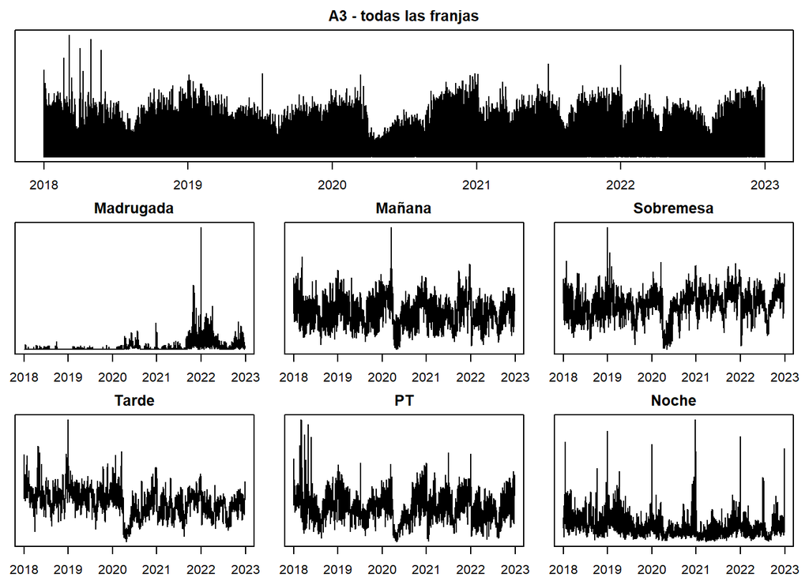

```r
root.path <- "J:/PMED_Practices/Data_Sciences/Advanced Analytics/Ninah/PROYECTOS AA/Proyecto Colaboracion UCM/01 Proyecto TV alpha"
data.path <- "01.1 datos procesados"

datos.18.22 <- readRDS(file.path(root.path,data.path,"grp_2018-01-01_2022-12-31.RDS"))

datos.18.22 <- filter(datos.18.22, Cadena %in% c("A3","CUATRO","LA SEXTA","T5"))

series.viz <- function(cadena.x){
  all.day <- datos.18.22 %>% filter(Cadena==cadena.x)
  sunrise <- datos.18.22 %>% filter(Cadena==cadena.x, Franja=="Madrugada (De 02:30h a 07:00h)")
  morning <- datos.18.22 %>% filter(Cadena==cadena.x, Franja=="Mañana (De 07:00h a 14:00h)")
  lunch <- datos.18.22 %>% filter(Cadena==cadena.x, Franja=="Sobremesa (De 14:00h a 17:00h)")
  afternoon <- datos.18.22 %>% filter(Cadena==cadena.x, Franja=="Tarde (De 17:00h a 20:30h)")
  dinner <- datos.18.22 %>% filter(Cadena==cadena.x, Franja=="PT (20:30-24:30)")
  night <- datos.18.22 %>% filter(Cadena==cadena.x, Franja=="Noche (24:30-26:30)")

  layout(matrix(c(1,1,1,2,3,4,5,6,7),nrow=3,ncol=3,byrow=T))
  par(mar=c(2,1,2,1))
  plot(x=all.day$Fecha,y=all.day$GRP,type="l", main=paste0(cadena.x," - todas las franjas"), xlab="",ylab="",yaxt="n")
  plot(x=sunrise$Fecha,y=sunrise$GRP,type="l", main="Madrugada", xlab="",ylab="",yaxt="n")
  plot(x=morning$Fecha,y=morning$GRP,type="l", main="Mañana", xlab="",ylab="",yaxt="n")
  plot(x=lunch$Fecha,y=lunch$GRP,type="l", main="Sobremesa", xlab="",ylab="",yaxt="n")
  plot(x=afternoon$Fecha,y=afternoon$GRP,type="l", main="Tarde", xlab="",ylab="",yaxt="n")
  plot(x=dinner$Fecha,y=dinner$GRP,type="l", main="PT", xlab="",ylab="",yaxt="n")
  plot(x=night$Fecha,y=night$GRP,type="l", main="Noche", xlab="",ylab="",yaxt="n")
}

series.viz("A3")
```

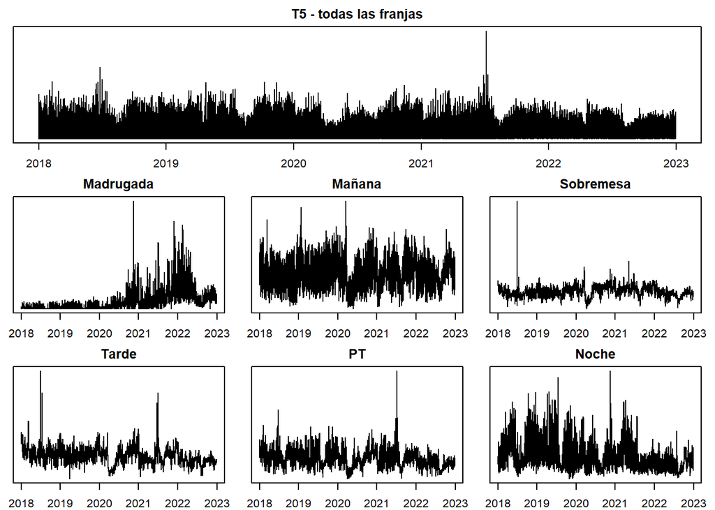

```r
series.viz("T5")
```

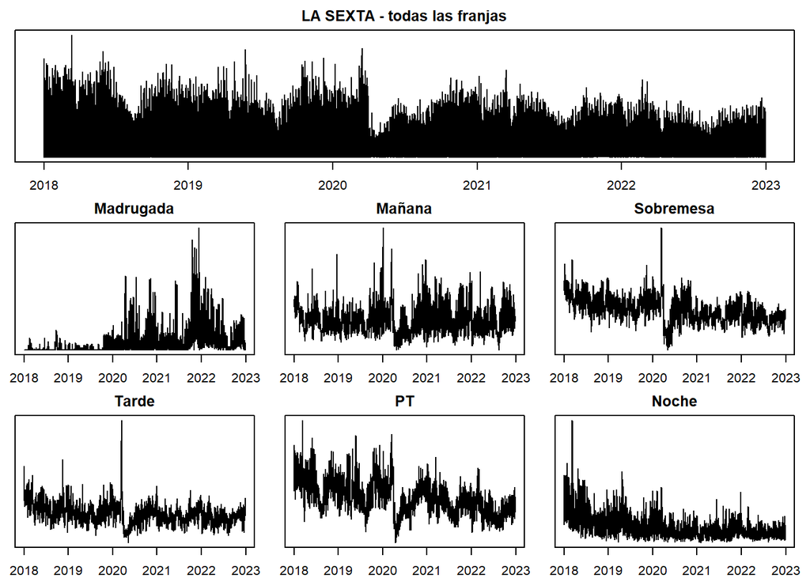

```r
series.viz("LA SEXTA")
```

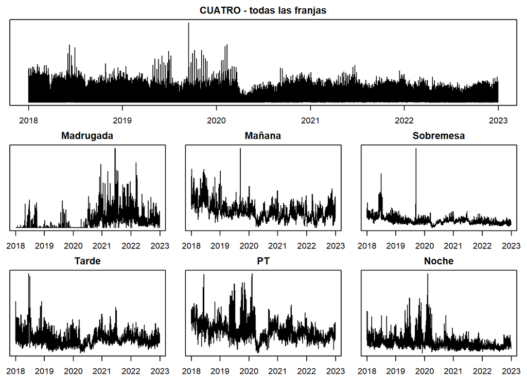

```r
series.viz("CUATRO")
```

# 3 Días de la semana

Vamos a estudiar cuáles son los días de la semana con más y con menos GRP, por cadena, durante todo el periodo 2018-2022.  
En general, hay más GRP de lunes a viernes que en el fin de semana aunque este resultado está influenciado por la franja donde hay más GRP, que es *prime time*. De hecho este resultado varía según la franja: como veremos luego, el día de la semana con más o menos GRP cambia según la franja que se observe.

```r
datos.18.22[,"day.of.week"] <- strftime(datos.18.22$Fecha,'%A')

rbind(
  datos.18.22 %>% filter(Cadena=="A3") %>% group_by(Cadena,day.of.week) %>%
    summarise(suma.GRP=sum(GRP), max.GRP=max(GRP), media.GRP=mean(GRP)) %>% arrange(desc(suma.GRP)),

  datos.18.22 %>% filter(Cadena=="LA SEXTA") %>% group_by(Cadena,day.of.week) %>%
    summarise(suma.GRP=sum(GRP), max.GRP=max(GRP), media.GRP=mean(GRP)) %>% arrange(desc(suma.GRP)),

  datos.18.22 %>% filter(Cadena=="T5") %>% group_by(Cadena,day.of.week) %>%
    summarise(suma.GRP=sum(GRP), max.GRP=max(GRP), media.GRP=mean(GRP)) %>% arrange(desc(suma.GRP)),

  datos.18.22 %>% filter(Cadena=="CUATRO") %>% group_by(Cadena,day.of.week) %>%
    summarise(suma.GRP=sum(GRP), max.GRP=max(GRP), media.GRP=mean(GRP)) %>% arrange(desc(suma.GRP)),
) |> as.data.frame() |> kable(row.names = FALSE) |> kable_styling(full_width = FALSE) |> scroll_box(height = "200px")
```

| Cadena | day.of.week | suma.GRP | max.GRP | media.GRP |
| --- | --- | --- | --- | --- |
| A3 | lunes | 341419.9 | 1010.1 | 218.02037 |
| A3 | martes | 336276.0 | 1410.4 | 214.73563 |
| A3 | miércoles | 333389.6 | 942.5 | 212.89246 |
| A3 | jueves | 320592.5 | 1075.3 | 204.72063 |
| A3 | viernes | 315303.5 | 1061.7 | 201.34323 |
| A3 | domingo | 306961.9 | 844.0 | 196.77045 |
| A3 | sábado | 278259.7 | 1235.2 | 177.68819 |
| LA SEXTA | lunes | 180179.5 | 612.1 | 115.05715 |
| LA SEXTA | jueves | 165638.5 | 531.4 | 105.77171 |
| LA SEXTA | martes | 165430.2 | 466.5 | 105.63870 |
| LA SEXTA | miércoles | 165411.5 | 481.0 | 105.62676 |
| LA SEXTA | viernes | 153416.7 | 453.4 | 97.96724 |
| LA SEXTA | domingo | 137314.9 | 541.2 | 88.02237 |
| LA SEXTA | sábado | 130867.4 | 511.2 | 83.56794 |
| T5 | jueves | 413928.8 | 1189.5 | 264.32235 |
| T5 | miércoles | 383914.5 | 1181.4 | 245.15613 |
| T5 | martes | 381496.6 | 2230.8 | 243.61213 |
| T5 | lunes | 376818.2 | 1485.8 | 240.62465 |
| T5 | viernes | 348349.6 | 1144.2 | 222.44547 |
| T5 | domingo | 336739.6 | 1333.4 | 215.85872 |
| T5 | sábado | 287117.8 | 965.3 | 183.34470 |
| CUATRO | domingo | 177719.4 | 1001.8 | 113.92269 |
| CUATRO | sábado | 158257.9 | 725.9 | 101.05868 |
| CUATRO | martes | 152425.7 | 732.2 | 97.33442 |
| CUATRO | miércoles | 137846.5 | 461.4 | 88.02458 |
| CUATRO | lunes | 137814.2 | 445.1 | 88.00396 |
| CUATRO | jueves | 133461.4 | 395.5 | 85.22439 |
| CUATRO | viernes | 128274.2 | 432.7 | 81.91201 |

```r
datos.18.22[,"day.of.week"] <- NULL
```

# 4 Media y varianza

Las relaciones entre media y varianza de los GRP *sugieren que el modelo más apropiado de descomposición temporal puede ser el multiplicativo*. En los análisis que siguen, sin embargo, mantenemos el modelo aditivo tal y como se hizo en el primer desarrollo del proyecto.

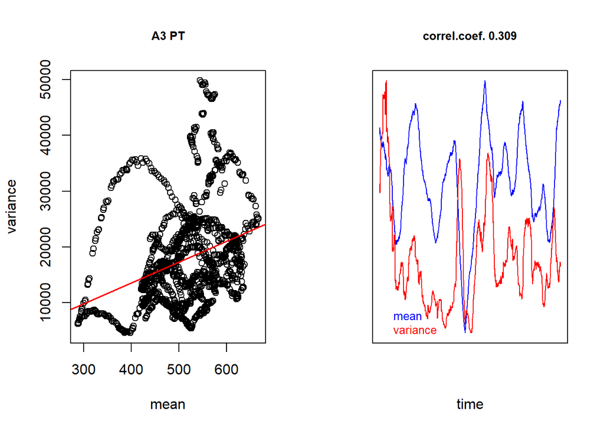

```r
viz.variance.mean <- function(serie,wd,cadena.x){
  require(zoo)
  par(mfrow=c(1,2))

  y <- zoo::rollapply(serie, width=wd, FUN=var)
  x <- zoo::rollapply(serie, width=wd, FUN=mean)
  plot(y~x,xlab="mean",ylab="variance",main=cadena.x,cex.main=0.8)
  abline(lm(y~x),col='red',lwd=1.5)

  plot(x,ylab="",xlab="time",main=paste("correl.coef.",round(cor(x,y),3)),col='blue',xaxt="n",yaxt="n",type='l',cex.main=0.8)
  par(new=TRUE)
  plot(y,ylab="",xlab="",main="",col='red',xaxt="n",yaxt="n",type='l')
  legend("bottomleft",legend=c("mean","variance"), bty='n', text.col=c('blue','red'),cex=0.8)
}

datos.18.22 %>% filter(Cadena=="A3", Franja=="PT (20:30-24:30)") %>% .[,"GRP",drop=TRUE] %>%
  viz.variance.mean(wd=90,cadena.x="A3 PT")
```

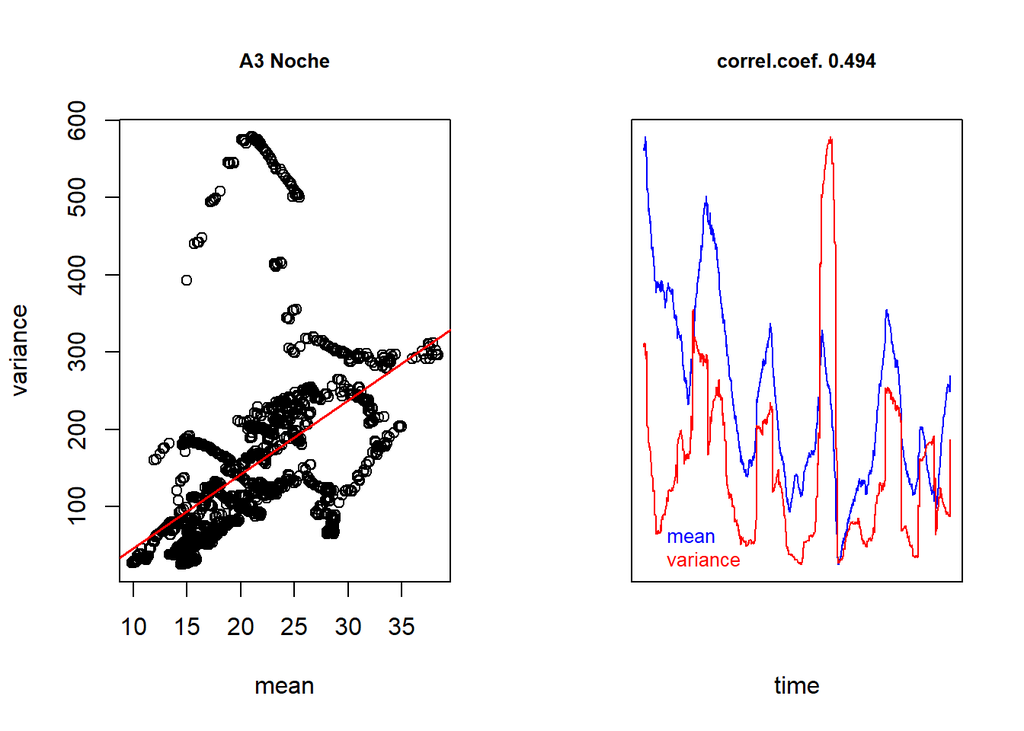

```r
datos.18.22 %>% filter(Cadena=="A3", Franja=="Noche (24:30-26:30)" ) %>% .[,"GRP",drop=TRUE] %>%
  viz.variance.mean(wd=90,cadena.x="A3 Noche")
```

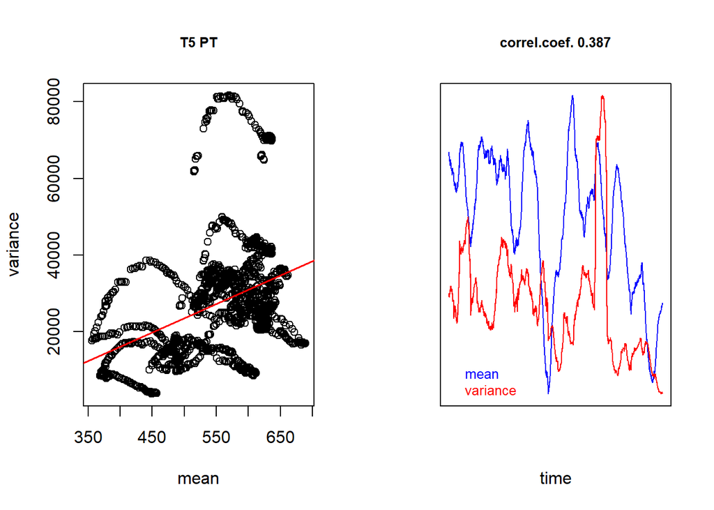

```r
datos.18.22 %>% filter(Cadena=="T5", Franja=="PT (20:30-24:30)") %>% .[,"GRP",drop=TRUE] %>%
  viz.variance.mean(wd=90,cadena.x="T5 PT")
```

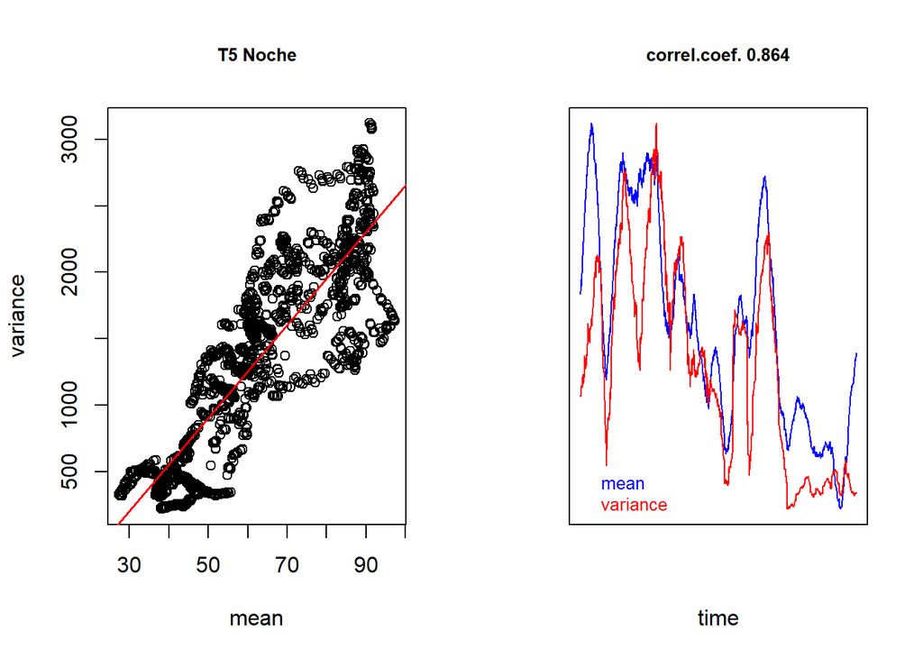

```r
datos.18.22 %>% filter(Cadena=="T5", Franja=="Noche (24:30-26:30)" ) %>% .[,"GRP",drop=TRUE] %>%
  viz.variance.mean(wd=90,cadena.x="T5 Noche")
```

# 5 Descomposición de las series temporales

Aplicando un modelo aditivo, vamos a comparar las *descomposiciones temporales de una cadena hechas con dos criterios*:

- criterio 1: descomponiendo la serie completa (con todas las franjas, 6 datos por día), obteniedo así tres componentes cíclicos (el diario, el semanal, y el anual), una tendencia y una serie de residuos;
- criterio 2: descomponiendo las series por franja (con 1 dato por día), obteniendo así dos componentes cíclicos (el semanal y el anual), una tendencia y una serie residual.

Este análisis sugiere que *el resultado de la descomposición puede variar sensiblemente según el criterio que se elija*. La componente intradiaria no es contrastable, pero la componente anual y la tendencia parecen manifestar diferencias importantes.  
Además, parece que la descomposición de la serie con datos diarios por franja (criterio 1) está influenciada por la franja con más GRP: la tendencia y la componente semanal obtenidas con el cirterio 1 se parecen a las obtenidas con el criterio 2 para la serie de GRP de *prime time*.

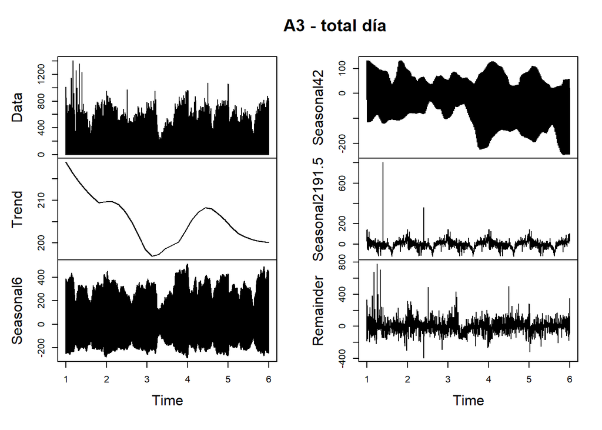

```r
all.day.descom.viz <- function(cadena.x){
  serie.x <- datos.18.22 %>% filter(Cadena==cadena.x)
  plot.name <- paste0(cadena.x," - total día")
  # y <- log(serie.x[,"GRP",drop=TRUE])
  # y[is.infinite(y)] <- 0
  # serie.x.ts <- msts(y, seasonal.periods = c(6, 6*7, 6*365.25))
  serie.x.ts <- msts(serie.x[,"GRP",drop=TRUE], seasonal.periods = c(6, 6*7, 6*365.25))
  serie.x.ts.mstl <- mstl(serie.x.ts, robust=TRUE)
  plot(serie.x.ts.mstl,main=plot.name)
  return(serie.x.ts.mstl)
}

franja.descom.viz <- function(cadena.x,franja.x){
  serie.x <- datos.18.22 %>% filter(Cadena==cadena.x, Franja==franja.x)
  plot.name <- paste0(cadena.x," - ",strsplit(franja.x," ")[[1]][1])
  # y <- log(serie.x[,"GRP",drop=TRUE])
  # y[is.infinite(y)] <- 0
  # serie.x.ts <- msts(y, seasonal.periods = c(7, 7*52.18))
  serie.x.ts <- msts(serie.x[,"GRP",drop=TRUE], seasonal.periods = c(7, 7*52.18))
  serie.x.ts.mstl <- mstl(serie.x.ts, robust=TRUE)
  plot(serie.x.ts.mstl,main=plot.name)
  return(serie.x.ts.mstl)
}

descom.dia <- all.day.descom.viz("A3")
```

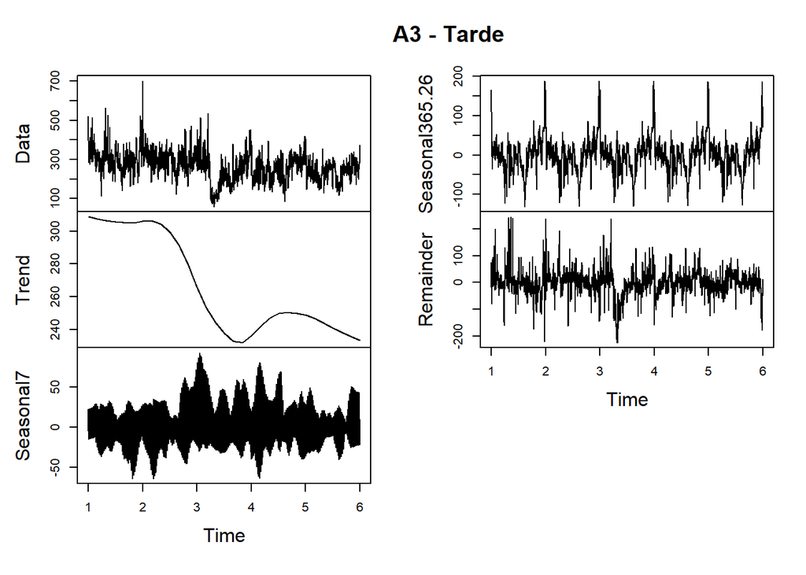

```r
descom.tarde <- franja.descom.viz(cadena.x = "A3", franja.x = "Tarde (De 17:00h a 20:30h)")
```

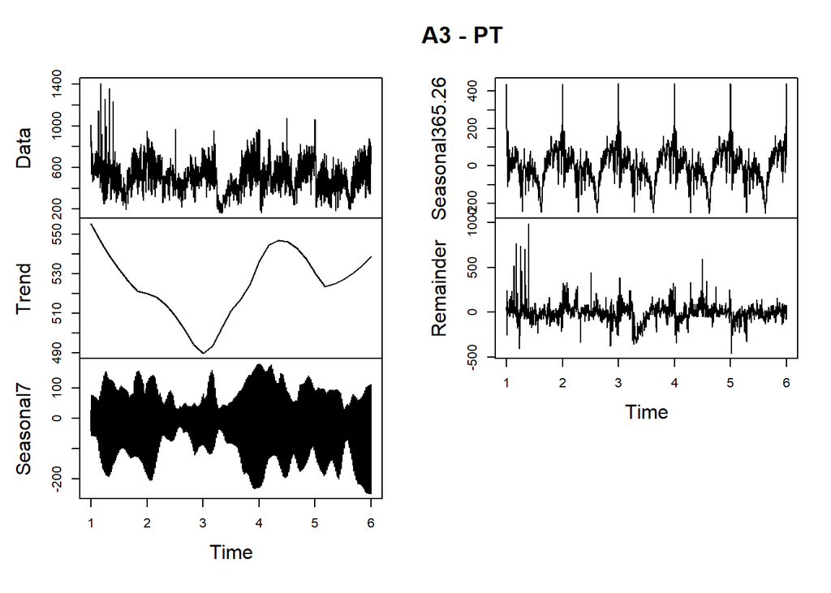

```r
descom.pt <- franja.descom.viz(cadena.x = "A3", franja.x = "PT (20:30-24:30)")
```

## 5.1 Componente `seasonal 6`

Vamos a estudiar la componente `seasonal 6` de la descomposición de la serie completa (criterio 1). En esta componente se recoge el comportamiento cíclico de los 6 datos por día, es decir cómo varían los GRP dentro de un mismo día, según la franja.  
La franja con más GRP es *prime time*, reflejado por los valores más altos de la componente. Además, como hemos anticipado antes en el estudio de los días de la semana, hay más GRP de lunes a viernes.

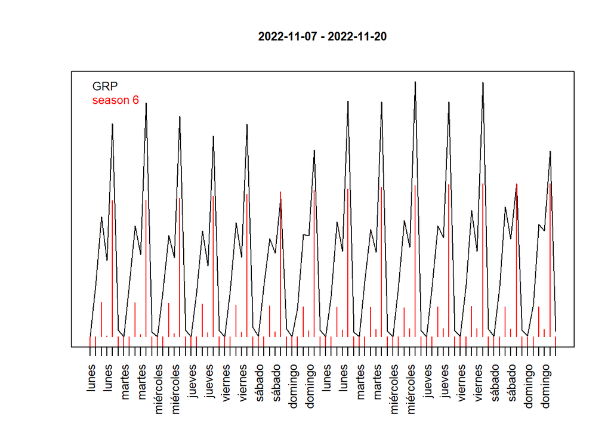

```r
cbind(datos.18.22 %>% filter(Cadena=="A3"),data.frame("Seasonal6"=descom.dia[,"Seasonal6"])) %>%
  filter(Fecha>=as.Date("2022-11-07") & Fecha<=as.Date("2022-11-20")) -> y

plot(y$GRP, type='l',ylab="",xlab="",yaxt="n",xaxt="n",main=paste(min(y$Fecha),max(y$Fecha),sep=" - "), cex.main=0.8, cex.axis=0.8)
lines(y$Seasonal6, type="h",col='red')
# axis(side=1,at=1:length(y$Fecha),labels=y$Fecha,cex.axis=0.8,las=2)
axis(side=1,at=1:length(y$Fecha),labels=strftime(y$Fecha,'%A'),cex.axis=0.8,las=2)
legend("topleft",legend=c("GRP","season 6"), bty='n', text.col=c('black','red'),cex=0.8)
```

## 5.2 Componente `seasonal 42`

Vamos a estudiar la componente `seasonal 42` de la descomposición de la serie completa (criterio 1). En esta componente se recoge el comportamiento de cada franja a lo largo de una semana, es decir en qué día de la semana hay más o menos GRP según la franja.  
Como hemos anticipado antes en el estudio de los días de la semana, es importante observar que **el fin de semana es el momento con menos GRP si se observa el *prime time* y en general en el día, pero el domingo es el día con más GRP si se observa la franja *tarde***.

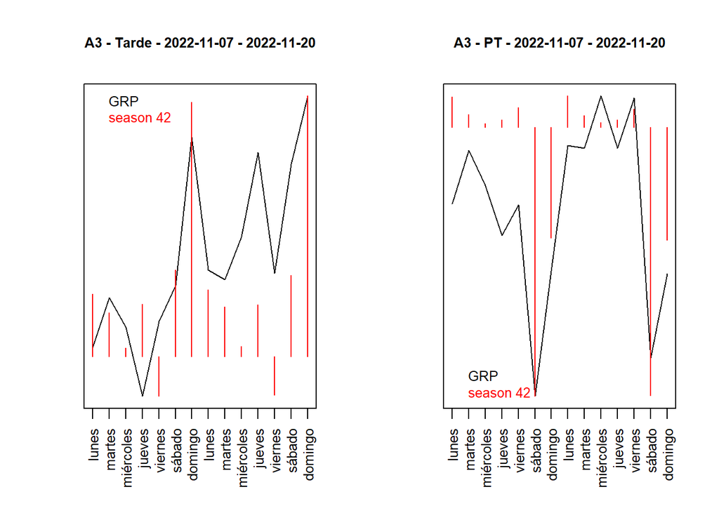

```r
cbind(datos.18.22 %>% filter(Cadena=="A3"),data.frame("Seasonal42"=descom.dia[,"Seasonal42"])) %>%
  filter(Fecha>=as.Date("2022-11-07") & Fecha<=as.Date("2022-11-20")) %>%
  filter(Franja=="Tarde (De 17:00h a 20:30h)" | Franja=="PT (20:30-24:30)")-> y

par(mfrow=c(1,2))

y[y$Franja=="Tarde (De 17:00h a 20:30h)","GRP",drop=TRUE] %>%
  plot(type='l',ylab="",xlab="",xaxt="n",yaxt="n",main=paste("A3","Tarde",min(y$Fecha),max(y$Fecha),sep=" - "), cex.main=0.8, cex.axis=0.8)
par(new=TRUE)
y[y$Franja=="Tarde (De 17:00h a 20:30h)","Seasonal42",drop=TRUE] %>%
  plot(type="h",col='red',ylab="",xlab="",xaxt="n",yaxt="n")
legend("topleft",legend=c("GRP","season 42"), bty='n', text.col=c('black','red'),cex=0.8)
foo <- strftime(y[y$Franja=="Tarde (De 17:00h a 20:30h)","Fecha",drop=TRUE], "%A")
axis(side=1,at=seq_along(foo),labels=foo,cex.axis=0.8,las=2)

y[y$Franja=="PT (20:30-24:30)","GRP",drop=TRUE] %>%
  plot(type='l',ylab="",xlab="",xaxt="n",yaxt="n",main=paste("A3","PT",min(y$Fecha),max(y$Fecha),sep=" - "), cex.main=0.8, cex.axis=0.8)
par(new=TRUE)
y[y$Franja=="PT (20:30-24:30)","Seasonal42",drop=TRUE] %>%
  plot(type="h",col='red',ylab="",xlab="",xaxt="n",yaxt="n")
legend("bottomleft",legend=c("GRP","season 42"), bty='n', text.col=c('black','red'),cex=0.8)
foo <- strftime(y[y$Franja=="PT (20:30-24:30)","Fecha",drop=TRUE], "%A")
axis(side=1,at=seq_along(foo),labels=foo,cex.axis=0.8,las=2)
```

## 5.3 Componente `seasonal 2191.5`

Vamos a estudiar la componente `seasonal 2191.5` de la descomposición de la serie completa (criterio 1). En esta componente se recoge el comportamiento de cada franja a lo largo de un año o, que es lo mismo, la estacionalidad del número de GRP durante el año.  
En primavera y erano los GRP son menos que en otoño-invierno. Aquí no hay grandes diferencias entre franjas, lo que indica que el comportamento estacional con base anual es más homogéneo, pero es importante destacar el *outlier* en el 2018, procedente de la serie de GRP en *prime time*.

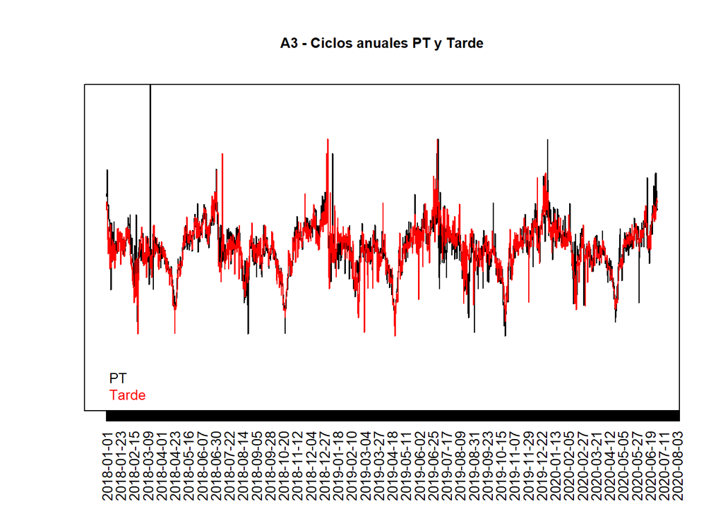

```r
cbind(datos.18.22 %>% filter(Cadena=="A3"),data.frame("Seasonal2191.5"=descom.dia[,"Seasonal2191.5"])) %>%
  filter(Franja=="Tarde (De 17:00h a 20:30h)" | Franja=="PT (20:30-24:30)")-> y

y[y$Franja=="PT (20:30-24:30)","Seasonal2191.5",drop=TRUE] %>%
  plot(type='l',ylim=c(-200,200),ylab="",yaxt="n",xlab="",xaxt="n",main="A3 - Ciclos anuales PT y Tarde",cex.main=0.8)
y[y$Franja=="Tarde (De 17:00h a 20:30h)","Seasonal2191.5",drop=TRUE] %>% lines(col='red')
legend("bottomleft",legend=c("PT","Tarde"), bty='n', text.col=c('black','red'),cex=0.8)
axis(side=1,at=seq_along(y$Fecha),labels=y$Fecha,cex.axis=0.8,las=2)
```

## 5.4 Componente `Trend`

Comparamos las componentes de tendencia obtenidas con los dos criterios de descomposición. En la visualización vamos a incluir la serie de GRP original, la tendencia obtenida con la descomposición y un suavizado calculado con una media móvil con ventana de 90 días.  
Este análisis revela que, **según la franja que se observe, la tendencia puede ser distinta**. Dado que con el criterio 1 de descomposición se obtiene una sóla tendencia, quizá ésta no sea precisa para todas las franjas.

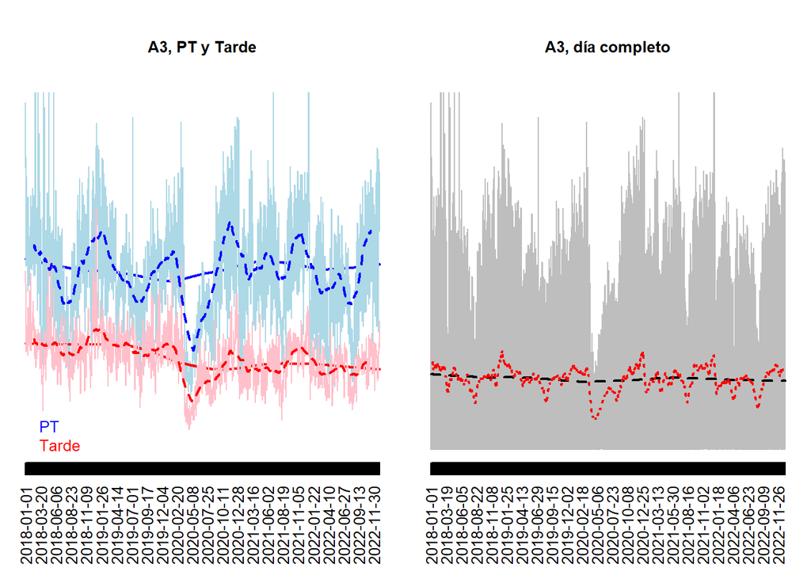

```r
cbind(
  cbind(datos.18.22 %>% filter(Cadena=="A3" & Franja=="PT (20:30-24:30)"),
        data.frame("PT.trend"=descom.pt[,"Trend"])) %>% select(-Franja) %>% mutate(GRP.PT=GRP,.keep="unused"),
  cbind(datos.18.22 %>% filter(Cadena=="A3" & Franja=="Tarde (De 17:00h a 20:30h)"),
        data.frame("tarde.trend"=descom.tarde[,"Trend"])) %>% select(-Franja) %>% mutate(GRP.Tarde=GRP,.keep="unused") %>% .[,3:4]
) -> y

y[,"PT.rollmean"] <- zoo::rollmean(y$GRP.PT,k=90,align="center",fill=NA)
y[,"Tarde.rollmean"] <- zoo::rollmean(y$GRP.Tarde,k=90,align="center",fill=NA)

cbind(datos.18.22 %>% filter(Cadena=="A3"),data.frame("Trend"=descom.dia[,"Trend"])) -> x

x[,"rollmean"] <- zoo::rollmean(x$GRP,k=90,align="center",fill=NA)

par(mfrow=c(1,2),mar=c(5,0.5,4,0.5))

matplot(y[,3:ncol(y)],type='l', ylim=c(0,1000), ylab="",xlab="",xaxt="n",yaxt="n",main="A3, PT y Tarde",cex.main=0.8,axes=FALSE,
        lty=c(1,1,1,1,2,2),
        col=c('blue','lightblue','red','pink','blue','red'),
        lwd=c(2,1,2,1,2,2))
axis(side=1,at=seq_along(y$Fecha),labels=y$Fecha,cex.axis=0.8,las=2)
legend("bottomleft",legend=c("PT","Tarde"), bty='n', text.col=c('blue','red'),cex=0.8)

matplot(x[,c("GRP","Trend","rollmean")],type='l',col=c("grey","black",'red'),axes=FALSE,ylab="",lwd=c(1,2,2),ylim=c(0,1000),main="A3, día completo",cex.main=0.8)
axis(side=1,at=seq_along(x$Fecha),labels=x$Fecha,cex.axis=0.8,las=2)
```

# 6 Conclusiones

Descomponer las series por separado (por franja, lo que aquí hemos definido *criterio 2*) parece más prudente, dadas las diferentes dinámicas que hay en cada una y que la aproximación multiestacional (`mstl`) podría no detectar, sobre todo en lo que se refiere a las tandencias.  
La ventaja de la aproximación `mstl` es la posibilidad de realizar el trabajo de manera “compacta”. En el primer desarrollo del proyecto, teníamos una grandísima cantidad de modelos: realizábamos un modelo por cada combinación cadena-franja-target. Además, en este análisis hemos confirmado que el `mstl` extrae bastante bien las características de las tres frecuencias estacionales definidas.  
Sin embargo ahora vamos a modelizar un sólo target, lo que reduciría mucho el número de modelos a realizar si siguiéramos el criterio 1 tal y como se hizo en el primer desarrollo. Y esto nos daría una importante ventaja en costes computacionales y de desarrollo.  
Por otro lado, si siguiéramos el criterio 2 (descomponer por franja) quizá podríamos llegar a un nivel de precisión mayor a la hora de definir (y proyectar en la fase de *forecast*) las tendencias. Esto volvería a aumentar el número de modelos a desarrollar  
En el primer desarrollo del proyecto tuvimos 30 cadenas, 7 targets, 6 franjas y 3 kpi (inversión, audiencia y ocupación). Dos de los tres kpi (audiencia y ocupación) se modelizaron para cada combinación cadena-target. El kpi de inversión era un dato numérico segmentado a nivel fecha (diaria), cadena y sector; el sector se refería al sector económico o mercado del anunciante, y había 13 sectores (alimentación, automoción, bebidas, belleza, deportes, distribución, finanzas, hogar, limpieza, servicios, telecomunicaciones, textil, transporte). Se entrenó un modelo para cada combinación cadena-sector. Así finalmente había el numero de modelos en el primer desarrollo del proyecto fue:

```r
# 30 cadenas * 7 targets * 2 kpi + 30 cadenas * 13 sectores * 1 kpi
nrow(expand.grid(c(1:30),c(1:7)))*2 + nrow(expand.grid(c(1:30),c(1:13)))
```

```
## [1] 810
```

En esta nueva fase de desarrollo del proyecto, modelizamos un solo target (*ind. 4+*) y sólo dos kpi (audiencia e inversión; la ocupación se calcularía *a posteriori* a partir de las predicciones de los dos modelos según los criterios y definiciones elaborados por el equipo). Además, la inversión esta vez se va a modelizar con GRP segmentados a nivel fecha (diaria) y cadena.  
Si utilizáramos el `mstl` el número de modelos a desarrollar sería:

```r
# 30 cadenas * 1 target * 2 kpi
nrow(expand.grid(c(1:30),c(1:2)))
```

```
## [1] 60
```

Y si si eligiéramos descomponer las franjas por separado, el numero de modelos a desarrollar sería:

```r
# 30 cadenas * 1 target * 2 kpi * 6 franjas
nrow(expand.grid(c(1:30),c(1:6)))*2
```

```
## [1] 360
```

El coste computacional seguiría siendo inferior al original aunque eligiéramos la descomposición temporal por franjas.  
**La recomendación para el desarrollo del proyecto es realizar un modelo por combinación cadena-franja.**